# Predicting Housing Prices

### Overview

What really predicts the price of a house? The [Kaggle competition](https://www.kaggle.com/c/house-prices-advanced-regression-techniques) our group selected contends that it is more than just the number of bedrooms or a white picket fence. Through data exploration and multiple models, our group aims to find the best model to predict the price of residential houses in Ames, Iowa.

Our data set has 79 explanatory variables, including lot shape, basement square footage and kitchen quality, in addition to the number of bedrooms and bathrooms typically used to assess pricing. We aim to use this data set to find a model that effectively predicts our continuous variable of interest, SalePrice.

#### Loading data and libraries

```r
library(DataExplorer)
library(tidyverse)
library(caret)
library(corrplot)
library(gridExtra)
library(grid)
library(ggplot2)
library(lattice)
library(ModelMetrics)
library(randomForest)
library(xgboost)
library(e1071)

housing_data <- read.csv("train.csv")
```

### Exploratory Data Analysis

First, we check how many missing values we have in our dataset. We then create a table that shows which variables are missing data and how much each is missing. We will want to remove any variables that have a lot of missing values, since they will not provide much useful information for our models.

```
## Observations: 1,460
## Variables: 81
## $ Id            <int> 1, 2, 3, 4, 5, 6, 7, 8, 9, 10, 11, 12, 13, 14, 1...
## $ MSSubClass    <int> 60, 20, 60, 70, 60, 50, 20, 60, 50, 190, 20, 60,...
## $ MSZoning      <fct> RL, RL, RL, RL, RL, RL, RL, RL, RM, RL, RL, RL, ...
## $ LotFrontage   <int> 65, 80, 68, 60, 84, 85, 75, NA, 51, 50, 70, 85, ...
## $ LotArea       <int> 8450, 9600, 11250, 9550, 14260, 14115, 10084, 10...
## $ Street        <fct> Pave, Pave, Pave, Pave, Pave, Pave, Pave, Pave, ...
## $ Alley         <fct> NA, NA, NA, NA, NA, NA, NA, NA, NA, NA, NA, NA, ...
## $ LotShape      <fct> Reg, Reg, IR1, IR1, IR1, IR1, Reg, IR1, Reg, Reg...
## $ LandContour   <fct> Lvl, Lvl, Lvl, Lvl, Lvl, Lvl, Lvl, Lvl, Lvl, Lvl...
## $ Utilities     <fct> AllPub, AllPub, AllPub, AllPub, AllPub, AllPub, ...
## $ LotConfig     <fct> Inside, FR2, Inside, Corner, FR2, Inside, Inside...
## $ LandSlope     <fct> Gtl, Gtl, Gtl, Gtl, Gtl, Gtl, Gtl, Gtl, Gtl, Gtl...
## $ Neighborhood  <fct> CollgCr, Veenker, CollgCr, Crawfor, NoRidge, Mit...
```

[output cut: 68 more lines]

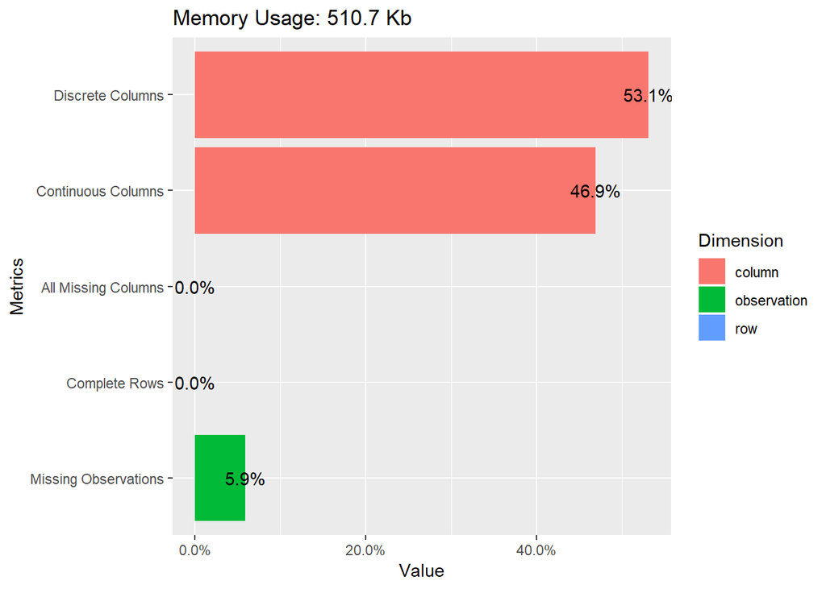

```r
NAcol <- which(colSums(is.na(housing_data)) > 0)
sort(colSums(sapply(housing_data[NAcol], is.na)), decreasing = TRUE)
```

```
##       PoolQC  MiscFeature        Alley        Fence  FireplaceQu
##         1453         1406         1369         1179          690
##  LotFrontage   GarageType  GarageYrBlt GarageFinish   GarageQual
##          259           81           81           81           81
##   GarageCond BsmtExposure BsmtFinType2     BsmtQual     BsmtCond
##           81           38           38           37           37
## BsmtFinType1   MasVnrType   MasVnrArea   Electrical
##           37            8            8            1
```

Based on the information above, we remove PoolQC, MiscFeature, Alley, Fence and FireplaceQu from our dataset as they offer little to no useful information.

```r
housing_data <- housing_data %>%
                select(-c('PoolQC','MiscFeature','Alley','Fence','FireplaceQu'))
```

Now, we check the distribution of categorical variables. We will want to remove any that don’t have much variance, since these will also not provide much useful information for our models.

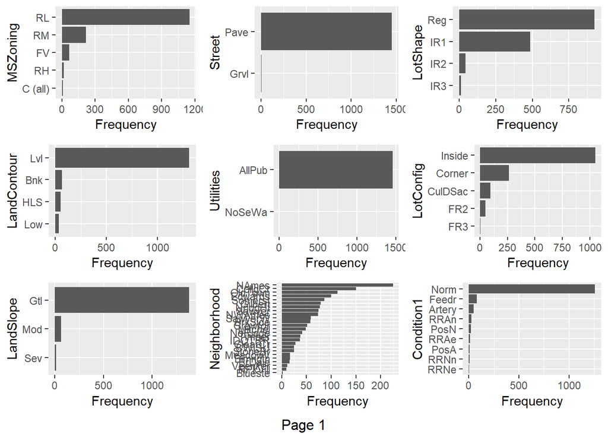

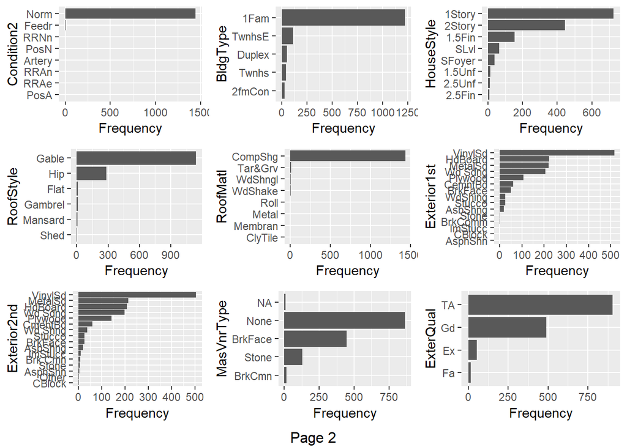

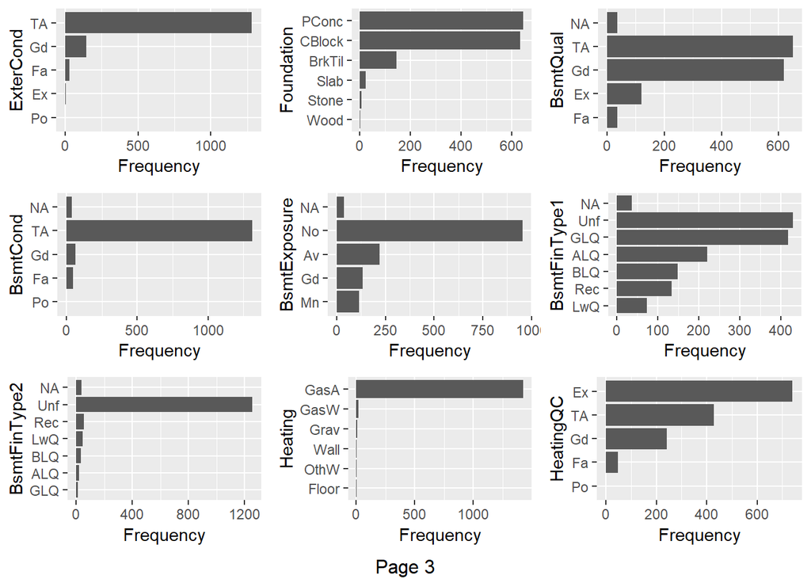

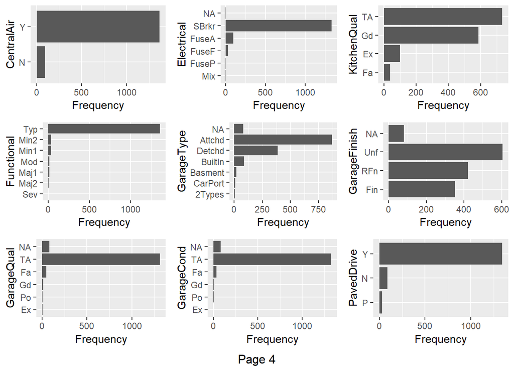

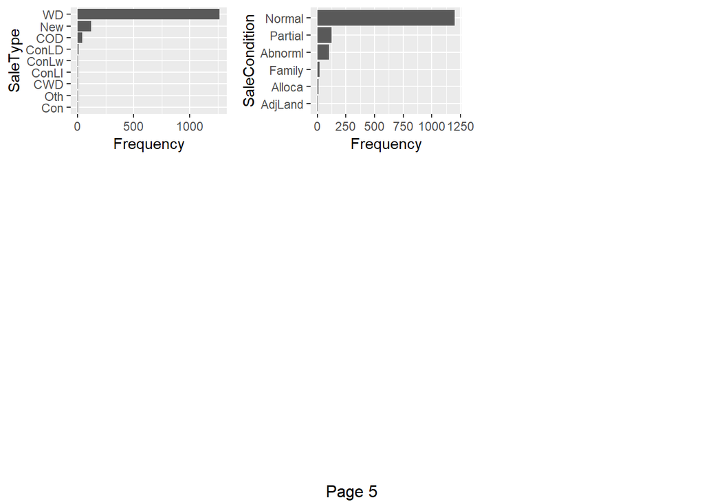

```r
plot_bar(housing_data)
```

Looking at above figures, we identify 5 variables where we have only one value or more than 95% of the data has single value. From modelling perspective, these will not offer any distinctive information, so we can remove them as well.

```r
table(housing_data$Street)
```

```
##
## Grvl Pave
##    6 1454
```

```r
table(housing_data$Utilities)
```

```
##
## AllPub NoSeWa
##   1459      1
```

```r
table(housing_data$Condition2)
```

```
##
## Artery  Feedr   Norm   PosA   PosN   RRAe   RRAn   RRNn
##      2      6   1445      1      2      1      1      2
```

```r
table(housing_data$RoofMatl)
```

```
##
## ClyTile CompShg Membran   Metal    Roll Tar&Grv WdShake WdShngl
##       1    1434       1       1       1      11       5       6
```

```r
table(housing_data$Heating)
```

```
##
## Floor  GasA  GasW  Grav  OthW  Wall
##     1  1428    18     7     2     4
```

```r
housing_data <- housing_data %>%
                select(-c('Street','Utilities','Condition2','RoofMatl','Heating','Id'))
```

Now, we will check the distribution of numerical variables for the same thing. Variables with little to no variance will not be helpful for modelling.

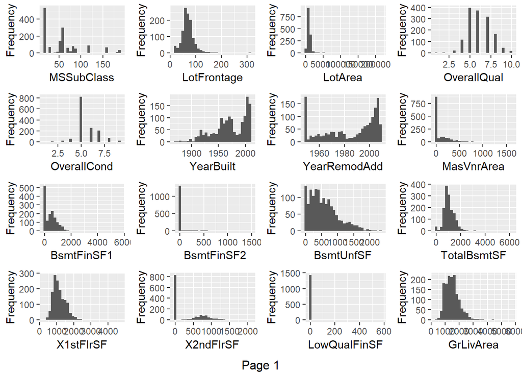

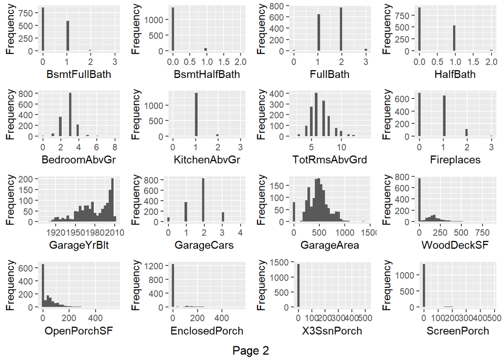

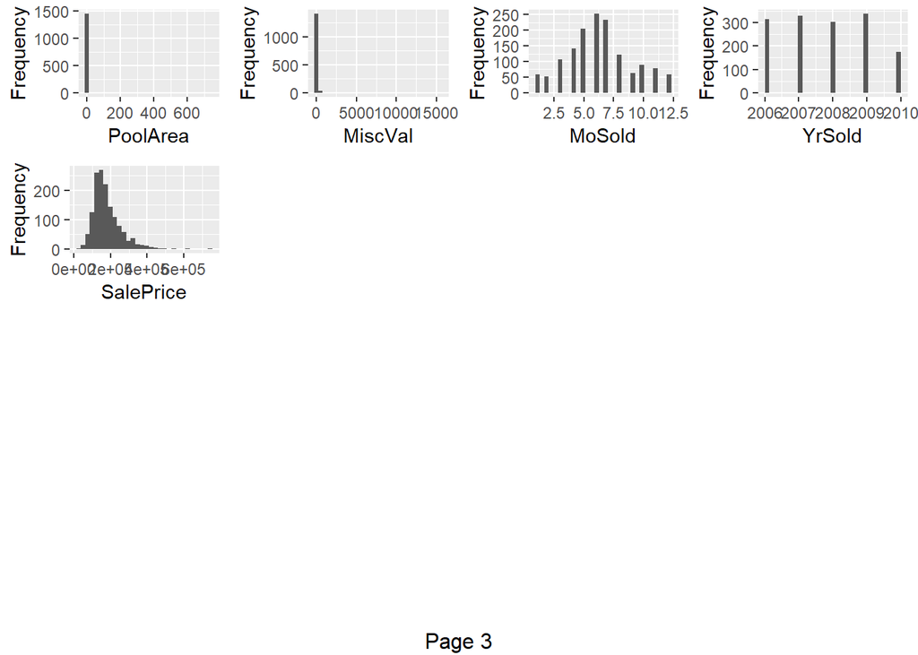

```r
plot_histogram(housing_data)
```

Looking through these histograms, we noticed there are few variables in which we have single value. Again, we remove these columns since they provide no additional value to our models.

```r
housing_data <- housing_data %>%
                select(-c('BsmtFinSF2','LowQualFinSF','X3SsnPorch','ScreenPorch','EnclosedPorch','PoolArea','MiscVal'))
```

Next, we want to further identify the predictors with zero or low variance. We are using nearZeroVar from the caret package to identify zero variance predictors.

```r
remove_cols <- nearZeroVar(housing_data, names = TRUE, freqCut = 10, uniqueCut = 20)
housing_data <- housing_data %>%
                select(-remove_cols)
```

After our data exploration and cleaning, we are left with the 46 variables that will be most helpful in building predictive models. After looking at previous histograms we also realized that a lot of numeric columns need to be converted into factor variables, so we will do that before proceeding.

```r
factor_cols <- c("OverallQual","OverallCond","BsmtFullBath","FullBath","HalfBath","BedroomAbvGr","Fireplaces",
                 "MoSold","YrSold")
housing_data <- housing_data %>%
                    mutate_each_(funs(factor(.)),factor_cols)
```

For the purposes of our modeling, we want to transform the data to a normal distribution so that we can more accurately predict the outcome. This will hopefully help prevent us from low-balling predictions on high-priced houses.

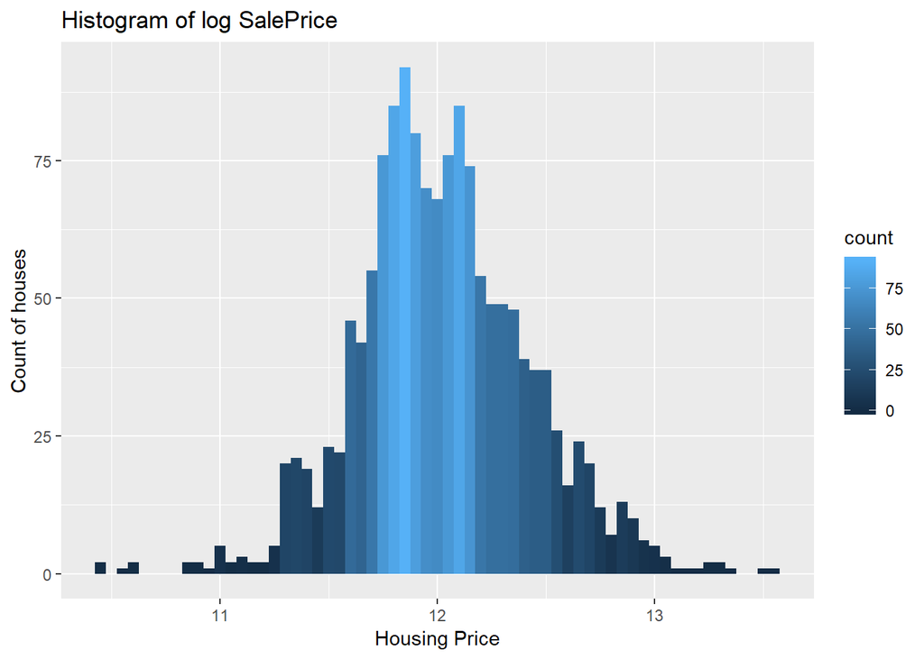

```r
lSalePrice <- log(housing_data$SalePrice)
ggplot(housing_data, aes(x = lSalePrice, fill = ..count..)) +
  geom_histogram(binwidth = 0.05) +
  ggtitle("Histogram of log SalePrice") +
  ylab("Count of houses") +
  xlab("Housing Price")
```

Log transformation makes our target variable normal. We will be using log(SalePrice) in our predictive model.

#### Univariate Analysis

Now, we will continue our robust EDA process with some univariate analyses in graphical form.

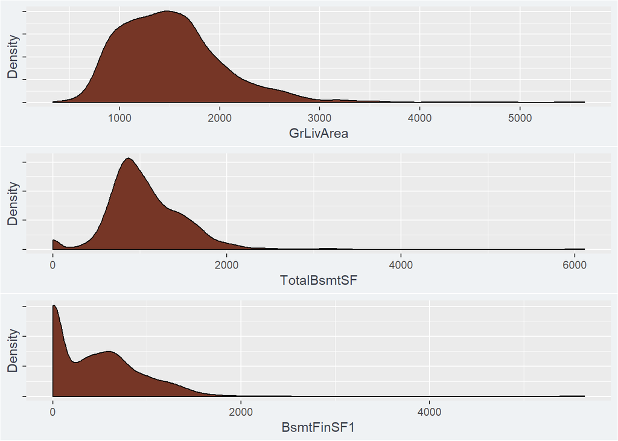

```r
d1 <- housing_data %>% ggplot(aes(GrLivArea)) + geom_density(fill='#763626') +
  theme( plot.background = element_rect(fill = "#EFF2F4"),axis.text.y = element_blank(),
         text = element_text(family = 'Ubuntu Condensed', face = 'plain', color = '#3A3F4A'))+ ylab("Density")

d2 <- housing_data %>% ggplot(aes(TotalBsmtSF)) + geom_density(fill='#763626') +
  theme( plot.background = element_rect(fill = "#EFF2F4"),axis.text.y = element_blank(),
         text = element_text(family = 'Ubuntu Condensed', face = 'plain', color = '#3A3F4A'))+ ylab("Density")

d3 <- housing_data %>% ggplot(aes(BsmtFinSF1)) + geom_density(fill='#763626') +
  theme( plot.background = element_rect(fill = "#EFF2F4"),axis.text.y = element_blank(),
         text = element_text(family = 'Ubuntu Condensed', face = 'plain', color = '#3A3F4A')) + ylab("Density")
grid.arrange(arrangeGrob(d1,d2,d3))
```

#### Bivariate Analysis

Now we will summarize SalePrice by different categorical variables - Foundation type, House Style, Roof Style and Garage Type - to see how they are distributed with respect to one another.

```r
by(housing_data$SalePrice,housing_data$HouseStyle,summary)
```

```
## housing_data$HouseStyle: 1.5Fin
##    Min. 1st Qu.  Median    Mean 3rd Qu.    Max.
##   37900  114625  132000  143117  159326  410000
## --------------------------------------------------------
## housing_data$HouseStyle: 1.5Unf
##    Min. 1st Qu.  Median    Mean 3rd Qu.    Max.
##   76000   98175  111250  110150  120500  139400
## --------------------------------------------------------
## housing_data$HouseStyle: 1Story
##    Min. 1st Qu.  Median    Mean 3rd Qu.    Max.
##   34900  127000  154750  175986  209350  611657
## --------------------------------------------------------
## housing_data$HouseStyle: 2.5Fin
##    Min. 1st Qu.  Median    Mean 3rd Qu.    Max.
##  104000  164250  194000  220000  223750  475000
## --------------------------------------------------------
## housing_data$HouseStyle: 2.5Unf
##    Min. 1st Qu.  Median    Mean 3rd Qu.    Max.
##  101000  125000  133900  157355  163500  325000
## --------------------------------------------------------
## housing_data$HouseStyle: 2Story
##    Min. 1st Qu.  Median    Mean 3rd Qu.    Max.
##   40000  159500  190000  210052  240000  755000
## --------------------------------------------------------
## housing_data$HouseStyle: SFoyer
##    Min. 1st Qu.  Median    Mean 3rd Qu.    Max.
##   75500  127500  135960  135074  148000  206300
## --------------------------------------------------------
## housing_data$HouseStyle: SLvl
##    Min. 1st Qu.  Median    Mean 3rd Qu.    Max.
##   91000  145000  164500  166703  178000  345000
```

```r
by(housing_data$SalePrice,housing_data$Foundation,summary)
```

```
## housing_data$Foundation: BrkTil
##    Min. 1st Qu.  Median    Mean 3rd Qu.    Max.
##   37900  102400  125250  132291  151250  475000
## --------------------------------------------------------
## housing_data$Foundation: CBlock
##    Min. 1st Qu.  Median    Mean 3rd Qu.    Max.
##   34900  122125  141500  149806  168000  402861
## --------------------------------------------------------
## housing_data$Foundation: PConc
##    Min. 1st Qu.  Median    Mean 3rd Qu.    Max.
##   78000  173000  205000  225230  262140  755000
## --------------------------------------------------------
## housing_data$Foundation: Slab
##    Min. 1st Qu.  Median    Mean 3rd Qu.    Max.
##   39300   89375  104150  107366  118885  198500
## --------------------------------------------------------
## housing_data$Foundation: Stone
##    Min. 1st Qu.  Median    Mean 3rd Qu.    Max.
##  102776  109625  126500  165959  233734  266500
## --------------------------------------------------------
## housing_data$Foundation: Wood
##    Min. 1st Qu.  Median    Mean 3rd Qu.    Max.
##  143000  153500  164000  185667  207000  250000
```

```r
by(housing_data$SalePrice,housing_data$RoofStyle,summary)
```

```
## housing_data$RoofStyle: Flat
##    Min. 1st Qu.  Median    Mean 3rd Qu.    Max.
##   82000  143000  185000  194690  242000  274970
## --------------------------------------------------------
## housing_data$RoofStyle: Gable
##    Min. 1st Qu.  Median    Mean 3rd Qu.    Max.
##   34900  128000  160000  171484  202500  755000
## --------------------------------------------------------
## housing_data$RoofStyle: Gambrel
##    Min. 1st Qu.  Median    Mean 3rd Qu.    Max.
##   40000  105500  139000  148909  193750  259500
## --------------------------------------------------------
## housing_data$RoofStyle: Hip
##    Min. 1st Qu.  Median    Mean 3rd Qu.    Max.
##   55000  139675  176500  218877  277875  745000
## --------------------------------------------------------
## housing_data$RoofStyle: Mansard
##    Min. 1st Qu.  Median    Mean 3rd Qu.    Max.
##  100000  145500  175000  180568  216000  265979
## --------------------------------------------------------
## housing_data$RoofStyle: Shed
##    Min. 1st Qu.  Median    Mean 3rd Qu.    Max.
##  190000  207500  225000  225000  242500  260000
```

```r
by(housing_data$SalePrice,housing_data$GarageType,summary)
```

```
## housing_data$GarageType: 2Types
##    Min. 1st Qu.  Median    Mean 3rd Qu.    Max.
##   87000  146250  159000  151283  170250  186700
## --------------------------------------------------------
## housing_data$GarageType: Attchd
##    Min. 1st Qu.  Median    Mean 3rd Qu.    Max.
##   60000  150000  185000  202893  235000  755000
## --------------------------------------------------------
## housing_data$GarageType: Basment
##    Min. 1st Qu.  Median    Mean 3rd Qu.    Max.
##   55993  132250  148000  160571  174000  359100
## --------------------------------------------------------
## housing_data$GarageType: BuiltIn
##    Min. 1st Qu.  Median    Mean 3rd Qu.    Max.
##   91000  180750  227500  254752  300719  582933
## --------------------------------------------------------
## housing_data$GarageType: CarPort
##    Min. 1st Qu.  Median    Mean 3rd Qu.    Max.
##   82000   95000  108000  109962  110000  164900
## --------------------------------------------------------
## housing_data$GarageType: Detchd
##    Min. 1st Qu.  Median    Mean 3rd Qu.    Max.
##   35311  110000  129500  134091  147700  475000
```

Understandbly, 2.5 story, finished houses have the highest mean sale price of $220,000. The houses with concrete foundations have the highest mean price of $225,230. Similarly, houses with Shed roof style have the highest mean sale price of $225,000 and Built-in Garage type has the highest mean price of $254,752.

This type of analysis helps us understand some of the ways each factor can affect the variable of interest.

Now, we will do a similar graphical analysis with bivariate data. We made box plots of SalePrice by some of the categorical varaiables discussed above.

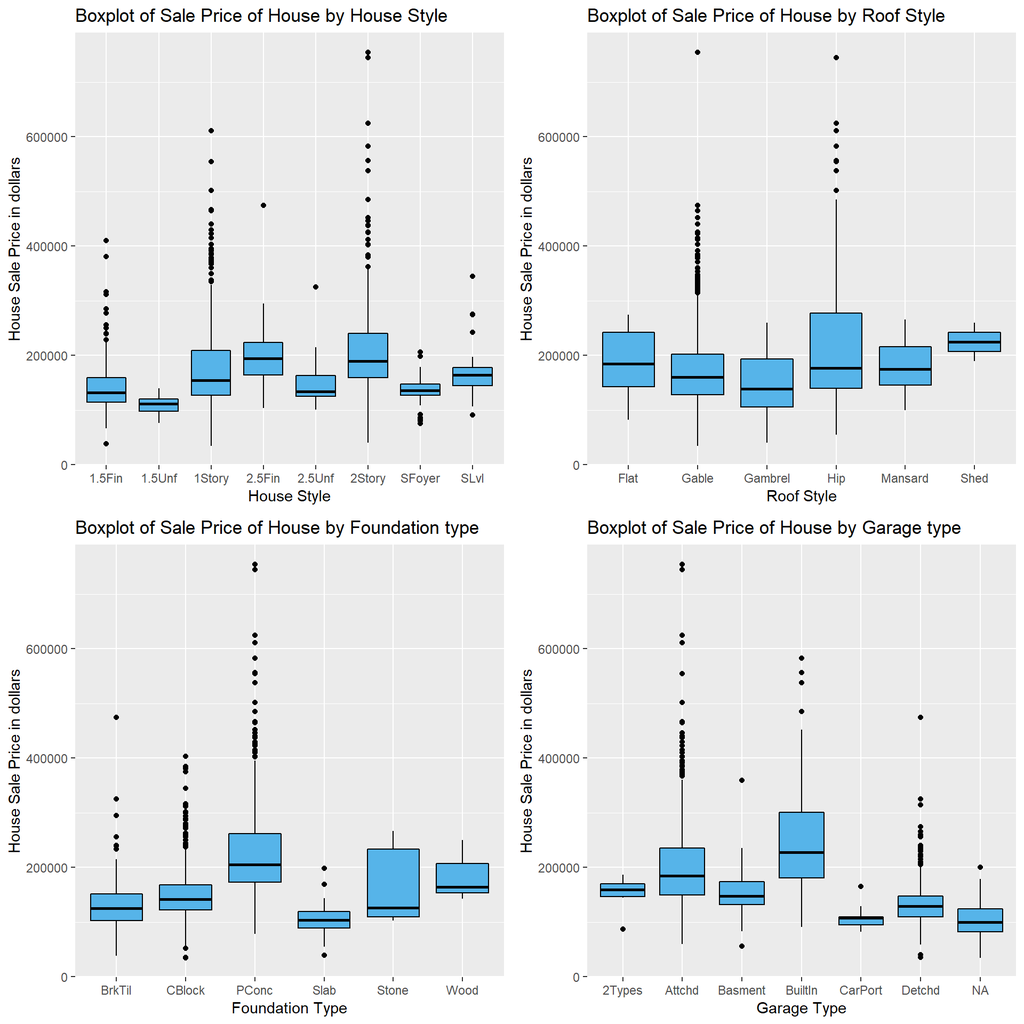

```r
options(scipen=999)

p1 <- ggplot(housing_data, aes(x = HouseStyle, y = SalePrice)) +
        geom_boxplot(colour = "black", fill = "#56B4E9") +
        scale_y_continuous(name = "House Sale Price in dollars") +
        scale_x_discrete(name = "House Style") +
        ggtitle("Boxplot of Sale Price of House by House Style")

p2 <- ggplot(housing_data, aes(x = RoofStyle, y = SalePrice)) +
        geom_boxplot(colour = "black", fill = "#56B4E9") +
        scale_y_continuous(name = "House Sale Price in dollars") +
        scale_x_discrete(name = "Roof Style") +
        ggtitle("Boxplot of Sale Price of House by Roof Style")

p3 <- ggplot(housing_data, aes(x = Foundation, y = SalePrice)) +
        geom_boxplot(colour = "black", fill = "#56B4E9") +
        scale_y_continuous(name = "House Sale Price in dollars") +
        scale_x_discrete(name = "Foundation Type") +
        ggtitle("Boxplot of Sale Price of House by Foundation type")

p4 <- ggplot(housing_data, aes(x = GarageType, y = SalePrice)) +
        geom_boxplot(colour = "black", fill = "#56B4E9") +
        scale_y_continuous(name = "House Sale Price in dollars") +
        scale_x_discrete(name = "Garage Type") +
        ggtitle("Boxplot of Sale Price of House by Garage type")
grid.arrange(p1,p2,p3,p4,ncol=2)
```

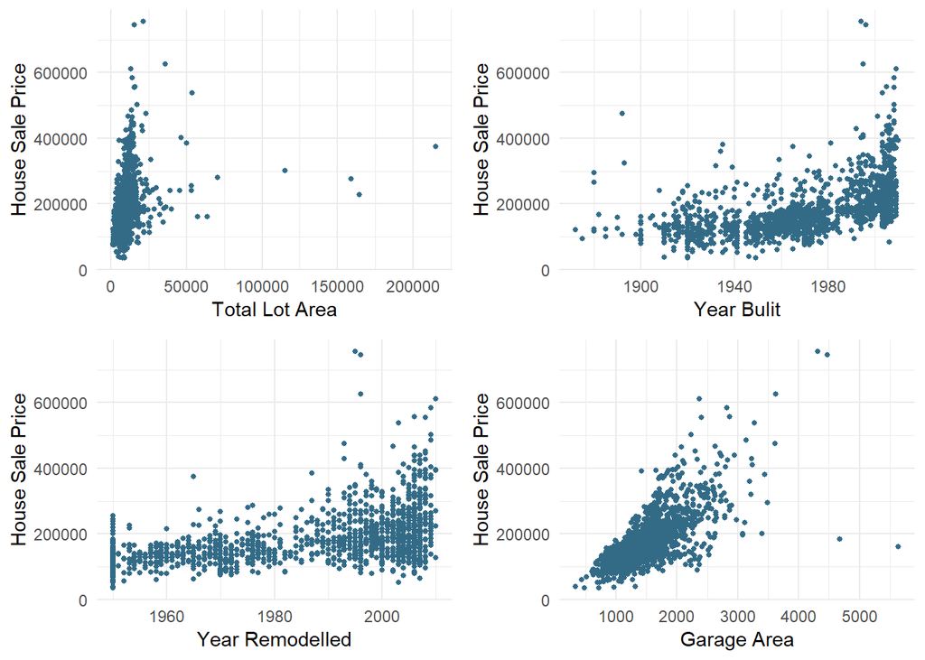

```r
options(scipen=999)

s1<-ggplot(housing_data, aes(LotArea, SalePrice)) +
  geom_point(shape = 16, size = 1, color = "#336B87",show.legend = FALSE) +
  theme_minimal() + xlab("Total Lot Area") + ylab("House Sale Price")


s2<-ggplot(housing_data, aes(YearBuilt, SalePrice)) +
  geom_point(shape = 16, size = 1, color = "#336B87",show.legend = FALSE) +
  theme_minimal() + xlab("Year Bulit") + ylab("House Sale Price")


s3<-ggplot(housing_data, aes(YearRemodAdd, SalePrice)) +
  geom_point(shape = 16, size = 1, color = "#336B87", show.legend = FALSE) +
  theme_minimal() + xlab("Year Remodelled") + ylab("House Sale Price")


s4<-ggplot(housing_data, aes(GrLivArea, SalePrice)) +
  geom_point(shape = 16, size = 1, color = "#336B87",show.legend = FALSE) +
  theme_minimal() + xlab("Garage Area") + ylab("House Sale Price")


grid.arrange(s1,s2,s3,s4,ncol=2)
```

#### Correlation Analysis

In the final part of our EDA, we will use correlation plots to see which variables have the highest correlation with our outcome of interest.

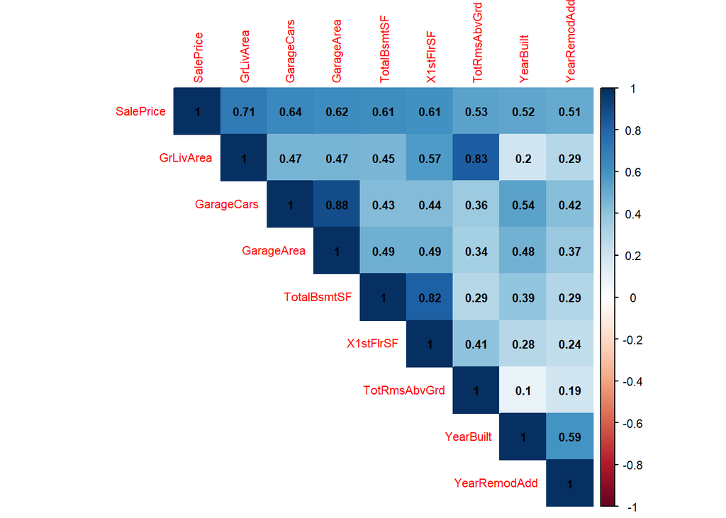

```r
output <- housing_data$SalePrice
num_features <- names(which(sapply(housing_data, is.numeric)))
cat_feature <- names(which(sapply(housing_data, is.factor)))
df.numeric <- housing_data[num_features]
df.factor <- housing_data[cat_feature]

correlations <- cor(df.numeric)
# only want the columns that show strong correlations with SalePrice
corr.SalePrice <- as.matrix(sort(correlations[,'SalePrice'], decreasing = TRUE))

corr.idx <- names(which(apply(corr.SalePrice, 1, function(x) (x > 0.5 | x < -0.5))))

corrplot(as.matrix(correlations[corr.idx,corr.idx]), type = 'upper', method='color', addCoef.col = 'black',
          tl.cex = .7,cl.cex = .7, number.cex=.7)
```

We reduced our corrplot to only showing variables with a correlation of 0.5 or more with the dependent variable. We expect these variables to be important and appear in our final model.

### Data Manipulation and Feature Engineering

In this section we explore some feature engineering - creating few more variables which we believe will help predict housing prices even more accurately.

We’ll start with neighborhoods, identifying which tend to be more expensive.

```r
neighbourhood_data <- housing_data[,c('Neighborhood','SalePrice')] %>%
  group_by(Neighborhood) %>%
  summarise(mean.price = round(mean(SalePrice, na.rm = TRUE))) %>%
  arrange(desc(mean.price))
neighbourhood_data
```

```
## # A tibble: 25 x 2
##    Neighborhood mean.price
##    <fct>             <dbl>
##  1 NoRidge          335295
##  2 NridgHt          316271
##  3 StoneBr          310499
##  4 Timber           242247
##  5 Veenker          238773
##  6 Somerst          225380
##  7 ClearCr          212565
##  8 Crawfor          210625
##  9 CollgCr          197966
## 10 Blmngtn          194871
## # ... with 15 more rows
```

Noridge, NridgeHt ,StoneBr , Timber and Veenker have higher mean housing prices than other neighbourhoods. We’ll create a new variable that bins neighborhoods into three different categories, depending on their mean housing values.

```r
housing_data$rich_neigh[housing_data$Neighborhood %in% c('StoneBr', 'NridgHt', 'NoRidge','Timber','Veenker')] <- 2
housing_data$rich_neigh[!housing_data$Neighborhood %in% c('MeadowV', 'IDOTRR', 'BrDale', 'StoneBr', 'NridgHt', 'NoRidge','Timber','Veenker','BrkSide','Edwards')]<- 1
housing_data$rich_neigh[housing_data$Neighborhood %in% c('MeadowV', 'IDOTRR', 'BrDale','BrkSide','Edwards')] <- 0
```

Next, we create another variable that captures the total square footage of the house, including living space and the basement area. This will give a better picture of how large the total house is.

```r
housing_data$TotalSqFeet <- housing_data$GrLivArea + housing_data$TotalBsmtSF
```

```r
housing_data$remodeled <- ifelse(housing_data$YearBuilt==housing_data$YearRemodAdd, 0, 1)
housing_data$house_age <- as.numeric(housing_data$YrSold)-housing_data$YearRemodAdd
```

New houses who were sold the same year they were built could be an indicator that these houses were hot in the market, or otherwise different from their counterparts. Therefore we want to create a variable that identifies whether a house was sold as new.

```r
housing_data$NewHouse <- (housing_data$YearBuilt == housing_data$YrSold) * 1
```

Since housing sales and moving tend to be seasonal, let’s explore in which months houses are typically sold.

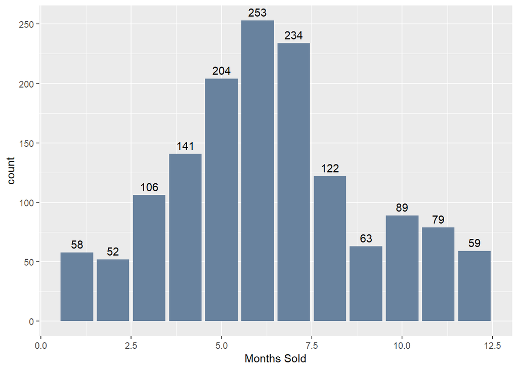

```r
ggplot(housing_data, aes(x=as.numeric(MoSold))) +
  geom_bar(fill = '#68829E') + xlab("Months Sold")+
  geom_text(aes(label=..count..), stat='count', vjust = -.5)
```

The largest proportion of houses sold is during the summer months: May, June, July. We are creating a variable to identify the summer season when maximum houses were sold.

```r
housing_data$highseason <- (housing_data$MoSold %in% c(5,6,7)) * 1
```

Now we will take care of removing skewness from our numeric variables which we have found out in our EDA.

```r
outcome <- housing_data$SalePrice

feature_classes <- sapply(names(housing_data),function(x){class(housing_data[[x]])})
numeric_feats <-names(feature_classes[feature_classes != "factor"])

# determine skew for each numeric feature
skewed_feats <- sapply(numeric_feats,function(x){skewness(housing_data[[x]],na.rm=TRUE)})

# keep only features that exceed a threshold for skewness
skewed_feats <- skewed_feats[skewed_feats > 0.75]

# transform excessively skewed features with log(x + 1)
for(x in names(skewed_feats)) {
  housing_data[[x]] <- log(housing_data[[x]] + 1)
}
housing_data$SalePrice <- outcome
```

Now we will remove all the variables from our model that we used to create these new variables. This will help us avoid the potential collinearity of factors that may affect our models’ success.

```r
housing_data <- housing_data %>%
                select(-c(MoSold,YrSold,YearRemodAdd,Neighborhood))
```

Now we will just replace any missing values with a value and move forward to model-building!

```r
housing_data <- set_missing(housing_data, list(0L, "unknown"))
```

#### Model Preparation

We begin our model preparation by dividing the data set into training and testing data, and transforming our outcome variable of interest.

```r
set.seed(15)
partition <- createDataPartition(y=outcome,p=.6,list=F)
training.set <- housing_data[partition,]
testing.set <- housing_data[-partition,]

training.set$log_SalePrice <- log(training.set$SalePrice)
training.set1 <- training.set %>%
  select(-SalePrice)
testing.set$log_SalePrice <- log(testing.set$SalePrice)
testing.set1 <- testing.set %>%
  select(-SalePrice)
```

We will now start with a linear model, looking at how each variable affects the dependent variable.

```r
lm_model_full <- lm(log_SalePrice ~ ., data=training.set1)
summary(lm_model_full)
```

```
##
## Call:
## lm(formula = log_SalePrice ~ ., data = training.set1)
##
## Residuals:
##      Min       1Q   Median       3Q      Max
## -0.92715 -0.05129  0.00060  0.05728  0.37015
##
## Coefficients: (4 not defined because of singularities)
##                          Estimate   Std. Error t value       Pr(>|t|)
## (Intercept)           3.979337940  1.316032966   3.024       0.002585 **
## MSSubClass           -0.020896444  0.012065523  -1.732       0.083714 .
## MSZoningFV            0.520067231  0.081275678   6.399 0.000000000281 ***
## MSZoningRH            0.412354452  0.088906164   4.638 0.000004171688 ***
## MSZoningRL            0.454083459  0.078693842   5.770 0.000000011727 ***
## MSZoningRM            0.393800741  0.077629155   5.073 0.000000498349 ***
## LotFrontage          -0.003801792  0.003021574  -1.258       0.208719
## LotArea               0.054083208  0.014261776   3.792       0.000162 ***
## LotShapeIR2          -0.000280611  0.027505003  -0.010       0.991863
## LotShapeIR3          -0.171428187  0.050153093  -3.418       0.000666 ***
## LotShapeReg          -0.001865380  0.010896911  -0.171       0.864127
## LotConfigCulDSac      0.013062216  0.021516080   0.607       0.543981
## LotConfigFR2         -0.035972846  0.027496678  -1.308       0.191199
## LotConfigFR3         -0.029856918  0.130459124  -0.229       0.819042
## LotConfigInside      -0.008240768  0.011838310  -0.696       0.486583
## HouseStyle1.5Unf      0.119932910  0.055209066   2.172       0.030153 *
## HouseStyle1Story      0.039219563  0.042002775   0.934       0.350750
## HouseStyle2.5Fin     -0.054907537  0.071295635  -0.770       0.441468
## HouseStyle2.5Unf      0.001818555  0.048979692   0.037       0.970393
## HouseStyle2Story     -0.039537342  0.021799157  -1.814       0.070136 .
## HouseStyleSFoyer      0.034318227  0.049994864   0.686       0.492658
## HouseStyleSLvl        0.038251185  0.041268110   0.927       0.354290
## OverallQual2          0.059114958  0.213025760   0.278       0.781474
## OverallQual3         -0.129405886  0.181203717  -0.714       0.475367
## OverallQual4         -0.043541166  0.182493168  -0.239       0.811490
## OverallQual5         -0.049905952  0.184555788  -0.270       0.786921
## OverallQual6         -0.008723803  0.184757101  -0.047       0.962353
## OverallQual7          0.041968590  0.185194884   0.227       0.820784
## OverallQual8          0.122593409  0.185740997   0.660       0.509448
## OverallQual9          0.219388053  0.189312409   1.159       0.246892
```

[output cut: 118 more lines]

```
## SaleConditionFamily   0.009869587  0.043663852   0.226       0.821237
## SaleConditionNormal   0.073531574  0.019773038   3.719       0.000216 ***
## SaleConditionPartial  0.138269325  0.031201733   4.431 0.000010806508 ***
## rich_neigh            0.046513753  0.011515078   4.039 0.000059309474 ***
## TotalSqFeet           0.149524828  0.211446375   0.707       0.479699
## remodeled            -0.025785865  0.012120332  -2.127       0.033716 *
## house_age            -0.001078620  0.000397805  -2.711       0.006858 **
## NewHouse             -0.099433687  0.043893864  -2.265       0.023787 *
## highseason            0.016191656  0.008981159   1.803       0.071827 .
## ---
## Signif. codes:  0 '***' 0.001 '**' 0.01 '*' 0.05 '.' 0.1 ' ' 1
##
## Residual standard error: 0.1194 on 725 degrees of freedom
## Multiple R-squared:  0.929,  Adjusted R-squared:  0.9141
## F-statistic: 62.38 on 152 and 725 DF,  p-value: < 0.00000000000000022
```

We can see how a new model performs when we drop a lot of variables that weren’t predictive in the last version. We will use RMSE to check how our linear model with just these variables performs.

```r
lm_model <- lm(log_SalePrice ~ MSSubClass+MSZoning+LotArea+LotConfig+OverallQual+YearBuilt+
                    MasVnrArea+remodeled+BsmtQual+X2ndFlrSF +FullBath+
                    KitchenQual+GarageType+GarageFinish+
                    SaleCondition+TotalSqFeet+highseason+BsmtFinSF1, data=training.set1)

prediction <- predict(lm_model, testing.set1, type="response")
model_output <- cbind(testing.set1, prediction)

model_output$log_prediction <- model_output$prediction

#Test with RMSE

rmse(testing.set$log_SalePrice,model_output$log_prediction)
```

```
## [1] 0.144198
```

An RMSE of 0.1442 with a linear model is not bad. We will explore other models to decrease RMSE.

Lets check the important variables using randomforest.

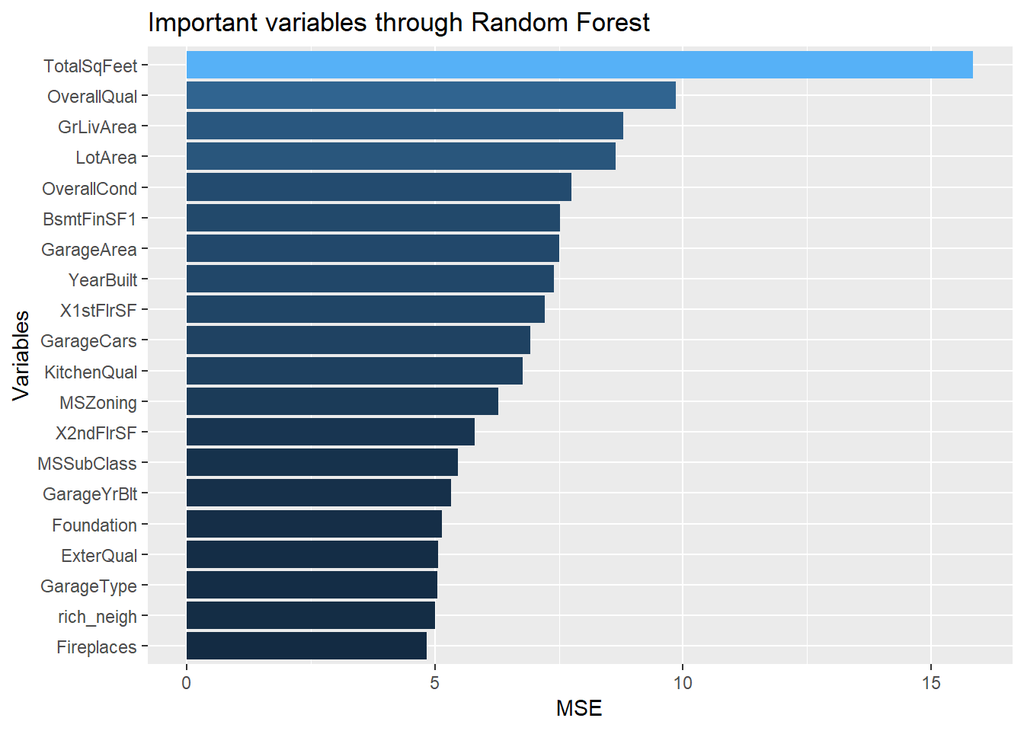

```r
set.seed(15)
quick_RF <- randomForest(x=training.set1[1:878,-48], y=training.set1$log_SalePrice[1:878], ntree=100,importance=TRUE)
imp_RF <- importance(quick_RF)
imp_DF <- data.frame(Variables = row.names(imp_RF), MSE = imp_RF[,1])
imp_DF <- imp_DF[order(imp_DF$MSE, decreasing = TRUE),]

ggplot(imp_DF[1:20,], aes(x=reorder(Variables, MSE), y=MSE, fill=MSE)) + geom_bar(stat = 'identity') + xlab('Variables')+
  coord_flip() + theme(legend.position="none")+ggtitle("Important variables through Random Forest")
```

#### Linear Regression Model

Again building a linear model, we are using all the variables identified by random forest and from the previous linear model. We will then check/compare the RMSE.

```r
lm_model_rf <- lm(log_SalePrice ~ BsmtFinSF1+BsmtFinType1+BsmtQual+ExterQual+FullBath+GrLivArea+
                              GarageArea+GarageCars+GarageFinish+GarageType+highseason+GarageYrBlt+Foundation+
                              KitchenQual+LotArea+LotConfig+MSSubClass+MSZoning+OverallCond+rich_neigh+Fireplaces+
                              OverallQual+remodeled+TotalSqFeet+X1stFlrSF+X2ndFlrSF +YearBuilt, data=training.set1)
prediction <- predict(lm_model_rf, testing.set1, type="response")
model_output <- cbind(testing.set1, prediction)

model_output$log_prediction <- model_output$prediction

#Test with RMSE
rmse(testing.set1$log_SalePrice,model_output$log_prediction)
```

```
## [1] 0.1321305
```

This RMSE is an improvement, with 0.1321 compared to 0.1442 in the previous linear model.

#### Models using H20 Library

Next, we are exploring h2o library to explore more advance models. As a first step, we are creating a H2o cluster and a training and testing dataset suitable for H2o algorithm.

```r
library(h2o)
localH2O <- h2o.init(nthreads = -1)
h2o.init()
train.h2o <- as.h2o(training.set1)
test.h2o <- as.h2o(testing.set1)
y.dep <- 48
#columns we want to use for prediction
x.indep <- c(22,21,19,16,30,28,40,39,38,36,47,37,18,33,4,6,1,2,9,42,35,8,44,43,26,27,10)
```

#### Random Forest using H20 library

```r
rforest.model <- h2o.randomForest(y=y.dep, x=x.indep, training_frame = train.h2o, ntrees = 1000, mtries = 3, max_depth = 4, seed = 15)
predict.rforest <- as.data.frame(h2o.predict(rforest.model, test.h2o))
model_output <- cbind(testing.set, predict.rforest$predict)

model_output$log_prediction <- model_output$predict.rforest
model_output$log_SalePrice <- log(model_output$SalePrice)

rmse(model_output$log_SalePrice,model_output$log_prediction)
```

```
## [1] 0.1605379
```

This RMSE actually got worse, so we will move forward to a different model.

#### GBM using H20 library

```r
gbm.model <- h2o.gbm(y=y.dep, x=x.indep, training_frame = train.h2o, ntrees = 1000, max_depth = 4, learn_rate = 0.01, seed = 15)
predict.gbm <- as.data.frame(h2o.predict(gbm.model, test.h2o))
model_output <- cbind(testing.set, predict.gbm$predict)

model_output$log_prediction <- (model_output$predict.gbm)
model_output$log_SalePrice <- log(model_output$SalePrice)

rmse(model_output$log_SalePrice,model_output$log_prediction)
```

```
## [1] 0.131366
```

This is the best model yet, in terms of RMSE, with a value of 0.1314 compared to the previous best of .1321.

#### XG Boost Model

As a final step, we will look at the XG Boost model to see how well we can predict our outcome variable of interest.

```r
set.seed(15)
trainData<- as.matrix(training.set1, rownames.force=NA)
testData<- as.matrix(testing.set1, rownames.force=NA)

#Turn the matrices into sparse matrices
train2 <- as(trainData, "sparseMatrix")
test2 <- as(testData, "sparseMatrix")

#columns we want to use for prediction


trainD <- xgb.DMatrix(data = train2[,x.indep], label = train2[,y.dep])

default_param<-list(
        objective = "reg:linear",
        booster = "gbtree",
        eta=0.05, #default = 0.3
        gamma=0,
        max_depth=3, #default=6
        min_child_weight=4, #default=1
        subsample=1,
        colsample_bytree=.7
)

model_xgb <-
  xgb.train(params =default_param,
            data = trainD,
            nrounds = 600,
            watchlist = list(train = trainD),
            verbose = TRUE,
            print_every_n = 50,
            nthread = 2)
testD <- xgb.DMatrix(data = test2[,x.indep])
prediction <- predict(model_xgb, testD)

#Put testing prediction and test dataset all together
test3 <- as.data.frame(as.matrix(test2))
prediction <- as.data.frame(as.matrix(prediction))
colnames(prediction) <- "prediction"
model_output <- cbind(test3, prediction)

#Test with RMSE

rmse(testing.set$log_SalePrice,model_output$prediction)
```

```
## [1] 0.1338843
```

### Conclusion and Next Steps

In the end we have four main models and performance of the models is mentioned below:  
Linear Regression with identified important variables RMSE: 0.1321  
Random Forest model using H20 library RMSE: 0.1605  
GBM model using H20 library RMSE: 0.1314  
XG BOOST Model RMSE: 0.1339

As we can see, the GBM model performed best among all other predictive models with respect to our performance measure of interests. We think that there is potential to better tune each of these models in order to get even better results, depending on the predictor’s needs. Model stacking could also be used to get an even better RMSE.

In general, our models did well with respect to RMSE, given the range of values of our predicted variable. We would select the GBM model results to submit to the Kaggle competition.

More broadly, We would recommend the model to realtors in the Ames, IA area. By plugging in values of the important variables for a house they are listing, realtors could quickly and easily come up with an ideal list price. This would take a lot of the guesswork out of determining a price that isn’t too high (risking scaring people away) but also isn’t too low (risking not maximizing revenue for the seller).

This could also be used by owners who want to sell their home directly, without paying pricey realtor fees. Even though they don’t have the knowledge of selling hundreds of houses, they would be able to price their house within reasonable range of what it should sell for.

For now, these results should not be generalized past Ames, IA, due to external validity concerns, but future applications could be done on data sets from different cities. A national data set would be even better, producing a pricing predictor of housing values in the U.S. for use in economic forecasts or the realtors/sellers as described above.